# 第五章 离散时间傅里叶变换

马越

北京理工大学机械与车辆学院  
Email: yuema@bit.edu.cn

## 目录

- **1. 非周期信号的表示：离散时间傅里叶变换**
- 2. 离散时间傅里叶变换的性质
- 3. 卷积性质
- 4. 乘积性质
- 5. 变换性质和变换对列表
- 6. 对偶性
- 7. 由线性常系数差分方程表征的系统

# 1. 非周期信号的表示：离散时间傅里叶变换

## 连续时间信号的采样

采样将连续时间 (CT) 信号转换为离散时间 (DT) 信号

连续时间信号

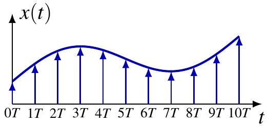

离散时间信号

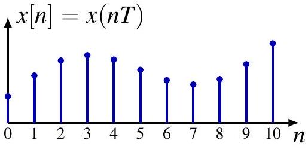

$T=$ 采样周期，均匀采样是最常用的方式。 采样技术使得我们可以利用数字电子设备来处理、记录、传输、存储和检索连续时间信号。

- 应用实例：MP3、数字相机、打印机

## 连续时间信号的采样

采样过程会损失信息，不同的信号可能会产生相同的样本序列：

- $x_{1}(t)=\cos \left(\frac{\pi}{3} t\right)$ 与 $x_{2}(t)=\cos \left(\frac{7 \pi}{3} t\right)$ 是不同的信号。
- 但它们的采样序列 $x_{1}[n]=\cos \left(\frac{\pi}{3} n\right)$ 与 $x_{2}[n]=\cos \left(\frac{7 \pi}{3} n\right)$ 是完全相同的。

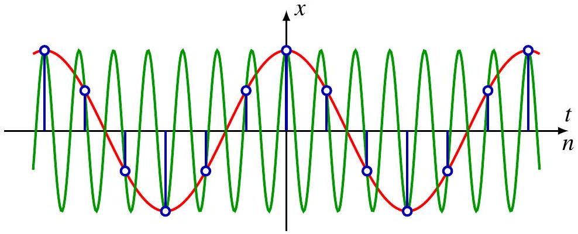

**关键问题：** 在什么条件下，我们才能从样本中完全恢复原信号？

## 冲激列采样

**时域分析**

连续时间信号 $x(t)$

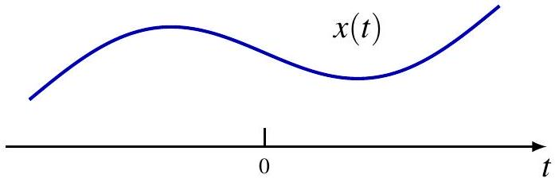

单位冲激串：
$$\begin{aligned}
& p(t)=\sum_{n=-\infty}^{\infty} \delta(t-n T) \\
& x_{p}(t)=x(t) p(t) \\
& =\sum_{n=-\infty}^{\infty} x(n T) \delta(t-n T)
\end{aligned}$$

## 冲激列采样

**频域分析**

连续时间信号频谱 $X(j \omega)$

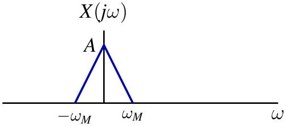

冲激串频谱：
$$\begin{aligned}
& P(j \omega)=\omega_{s} \sum_{k=-\infty}^{\infty} \delta\left(\omega-k \omega_{s}\right) \\
& X_{p}(j \omega)=\frac{1}{2 \pi}(X * P)(\omega) \\
& =\frac{1}{T} \sum_{k=-\infty}^{\infty} X\left(j\left(\omega-k \omega_{s}\right)\right)
\end{aligned}$$

## 冲激列采样

**频域限制与带宽**

带限连续信号：当 $|\omega|>\omega_{M}$ 时，$X(j \omega)=0$。

采样频率 $\omega_{s}=\frac{2 \pi}{T}$

**情况 1：** $\omega_{s}>2 \omega_{M}$ 频谱副本之间没有重叠，可以通过低通滤波器恢复 $X$。

**情况 2：** $\omega_{s}<2 \omega_{M}$ 频谱副本发生重叠（混叠），无法恢复 $X$。

## 采样定理

对于频谱满足 $X(j \omega)=0$（当 $|\omega|>\omega_{M}$ 时）的带限信号 $x(t)$，若满足以下条件，则该信号可由其样本 $x(n T), n \in \mathbb{Z}$ 唯一确定：

$$\omega_{s} \triangleq \frac{2 \pi}{T}>2 \omega_{M}, \quad 2 \omega_{M} \text{ 称为 奈奎斯特率 (Nyquist rate)}$$

给定样本序列 $\{x(n T)\}, x(t)$ 的重构步骤如下：

1. 构造冲激串信号 $x_{p}(t)=\sum_{n=-\infty}^{\infty} x(n T) \delta(t-n T)$
2. 将 $x_{p}$ 通过增益为 $T$、截止频率为 $\omega_{c} \in\left(\omega_{M}, \omega_{s}-\omega_{M}\right)$ 的低通滤波器：
   $$H(j \omega)=T\left[u\left(\omega+\omega_{c}\right)-u\left(\omega-\omega_{c}\right)\right]$$
3. 滤波器输出 $x_{r}(t)$ 即为原信号 $x(t)$。

## 频域中的重建

- 奈奎斯特频率：$\omega_{M}$
- 奈奎斯特率：$2 \omega_{M}$

**理想低通滤波器要求：** - 增益：$T$ - 截止频率范围：$\omega_{M}<\omega_{c}<\omega_{s}-\omega_{M}$

## 时域中的重建

低通滤波器的冲激响应：
$$h(t)=\frac{T \sin \left(\omega_{c} t\right)}{\pi t}$$

通过使用 sinc 函数的带限插值来恢复 $x$：
$$x(t)=x_{r}(t)=\left(x_{p} * h\right)(t)=\sum_{n=-\infty}^{\infty} x(n T) \frac{T \sin \left(\omega_{c}(t-n T)\right)}{\pi(t-n T)}$$

## 时域中的重建（Whittaker-Shannon）

当设置截止频率 $\omega_{c}=\frac{\omega_{s}}{2}=\frac{\pi}{T}$ 时，得到 **Whittaker-Shannon 插值公式**：
$$x_{r}(t)=\sum_{n=-\infty}^{\infty} x(n T) \operatorname{sinc}\left(\frac{t-n T}{T}\right), \quad \text{其中 } \operatorname{sinc}(t)=\frac{\sin (\pi t)}{\pi t}$$

该公式实际上是一个正交展开。

## 目录

1. 采样定理
2. 零阶保持与线性插值
3. 混叠

## 其他插值方法

除了理想的带限插值，实际工程中常用的方法还包括：

- 零阶保持 (Zero-order hold)
- 线性插值 (一阶保持)

## 零阶保持 (ZOH)

重构信号：
$$x_{0}(t)=\left(x_{p} * h_{0}\right)(t)=\sum_{n=-\infty}^{\infty} x(n T) h_{0}(t-n T)$$

零阶保持滤波器响应：
$$H_{0}(j \omega)=e^{-j \omega T / 2} \frac{2 \sin (\omega T / 2)}{\omega}$$

## 线性插值 (一阶保持 FOH)

重构信号：
$$x_{1}(t)=\left(x_{p} * h_{1}\right)(t)=\sum_{n=-\infty}^{\infty} x(n T) h_{1}(t-n T)$$

一阶保持滤波器响应：
$$H_{1}(j \omega)=\frac{1}{T}\left[\frac{\sin (\omega T / 2)}{\omega / 2}\right]^{2}$$

## 混叠 (Aliasing)

混叠会导致频率“折叠”：

- 当输入频率 $\omega_{0} < \frac{1}{2} \omega_{s}$ 时：可以正确重构。
- 当输入频率 $\omega_{0} > \frac{1}{2} \omega_{s}$ 时：重构信号会出现错误的频率 $x_{r}(t)=\cos \left(\left(\omega_{s}-\omega_{0}\right) t-\phi\right)$。

**实例：** 在电影中，快速转动的车轮看起来可能转得很慢，甚至反向旋转。

## 抗混叠滤波器 (Anti-aliasing Filter)

在采样之前，先通过滤波器滤除高于 $\frac{\omega_{s}}{2}$ 的频率分量，以防止混叠发生。

## DTFT 的卷积性质

$$(x * h)[n] \stackrel{\mathcal{F}}{\longleftrightarrow} X\left(e^{j \omega}\right) H\left(e^{j \omega}\right)$$

**注意：** 这是连续时间傅里叶级数 (CTFS) 乘积性质的对偶。

## LTI 系统的频率响应

LTI 系统 $T$ 可以由以下方式完全表征： - 冲激响应 $h$ - 频率响应 $H=\mathcal{F}\{h\}$（如果 $H$ 存在）

通常，卷积性质意味着：
$$Y = H X$$
与其计算繁琐的时域卷积 $x * h$，我们可以通过以下步骤获得输出：
$$y=\mathcal{F}^{-1}(H \cdot X)$$

## DTFT 的乘积性质

$$x[n] y[n] \stackrel{\mathcal{F}}{\longleftrightarrow} \frac{1}{2 \pi} X \circledast Y = \frac{1}{2 \pi} \int_{2 \pi} X\left(e^{j \theta}\right) Y\left(e^{j(\omega-\theta)}\right) d \theta$$

**注意：** 这是 CTFS 周期卷积性质的对偶。

## 线性常系数差分方程描述的系统

对于由下式描述的 LTI 系统：
$$\sum_{k=0}^{N} a_{k} y[n-k]=\sum_{k=0}^{M} b_{k} x[n-k]$$

其频率响应 $H(e^{j\omega})$ 是 $e^{-j\omega}$ 的有理函数：
$$H\left(e^{j \omega}\right)=\frac{\sum_{k=0}^{M} b_{k} e^{-j \omega k}}{\sum_{k=0}^{N} a_{k} e^{-j \omega k}}$$

## 抽取 (Decimation)

抽取通过减少样本点来降低采样率： 1. 先进行采样：$x_{p}[n]=\sum_{k=-\infty}^{\infty} x[k N] \delta[n-k N]$ 2. 得到抽取信号：$x_{b}[n]=x[n N]$

频谱关系：
$$X_{b}(e^{j \omega}) = X_{p}(e^{j \omega / N})$$
如果不发生混叠，$X_{b}$ 是 $X$ 在每个周期内的展宽版本。

## 连续时间信号的离散时间处理

离散时间处理的优点： - 数字电子设备的通用性 - 较强的抗噪声能力

**实际结构：** - **C/D 转换：** 由模数转换器 (ADC) 实现。 - **离散处理：** 使用 DSP 或计算机。 - **D/C 转换：** 由数模转换器 (DAC) 实现。

**理想化假设：** - 无量化误差 - C/D 建模为冲激串采样 - D/C 建模为理想低通重构

## 频率响应映射

整体连续时间系统的等效频率响应 $H_{c}(j \omega)$ 与离散时间频率响应 $H_{d}(e^{j \Omega})$ 的关系：
$$H_{c}(j \omega)= \begin{cases}H_{d}\left(e^{j \omega T}\right) & |\omega|<\frac{\omega_{s}}{2} \\ 0, & \text{其他}\end{cases}$$

即离散时间系统的频率响应是连续时间响应在频率上的归一化映射：
$$H_{d}\left(e^{j \Omega}\right)=H_{c}\left(j \frac{\Omega}{T}\right),|\Omega|<\pi$$

[output not shown]